# GAM modelling with mgcv and mgcViz

Matteo Fasiolo

July 02 2018

The `mgcv` R package offers methods for fitting GAM, using the methods described in [Wood, 2017](https://www.crcpress.com/Generalized-Additive-Models-An-Introduction-with-R-Second-Edition/Wood/p/book/9781498728331). It is convenient to use it together with `mgcViz`, which extends the basic visualizations provided by `mgcv`.

The main fitting functions are:

- `gam()` from the `mgcv` package fits an GAM models, and returns an object of class `gam`. See `?gamObject`.
- `gamV()` from the `mgcViz` package is a wrapper around `gam`. It returns `gamViz` objects, for which `mgcViz` provides lots of visualizations.

# An additive example with four covariates

We simulate some data from the model:
$$y = f_0(x_0)+f_1(x_1)+f_2(x_2)+f_3(x_3)+e,\;\;\; e \sim N(0, 2)$$
by doing

```r
library(mgcViz)
set.seed(2)
dat <- gamSim(1, n=1000, dist="normal", scale=2)[c("y", "x0", "x1", "x2", "x3")]
```

```
## Gu & Wahba 4 term additive model
```

We start by fitting a Gaussan linear model:

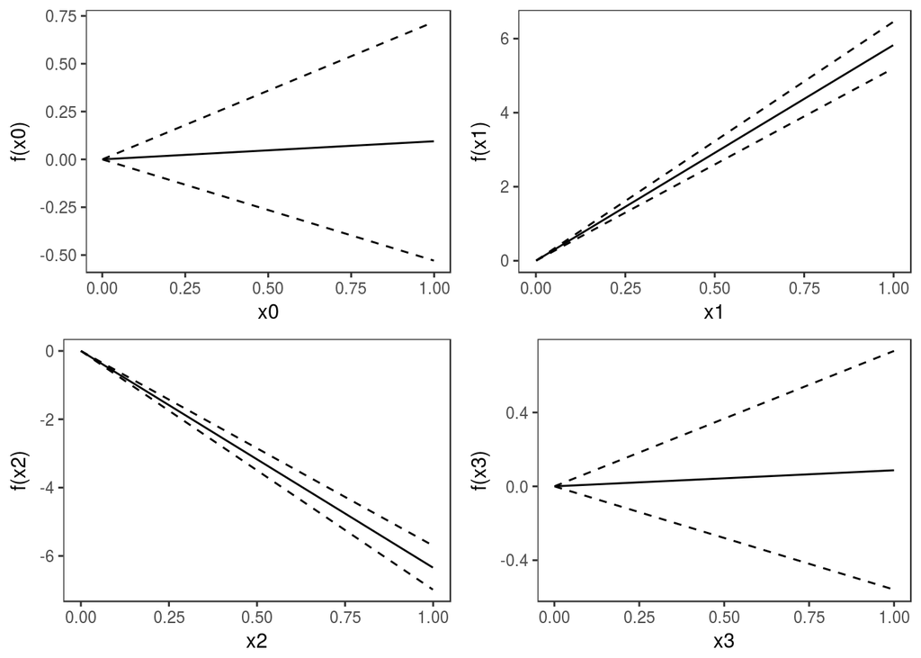

```r
fit1 <- gamV(y ~ x0 + x1 + x2 + x3,
             family = gaussian,
             data = dat,
             aViz = list(nsim = 50))

print(plot(fit1, allTerms = TRUE), pages = 1) # plot() calls plot.gamViz(). See ?plot.gamViz
```

We use `pages = 1` to plot on a single page, and `allTerms` to plot also the parametric effects (the plotting method used here plots only smooth or random effects by default).

Should we use a smooth effect of `x0`? If the effect of `x0` was non-linear, we would expect that the mean of the residuals would depart from 0, as we move along `x0`. We can use a marginal residual check:

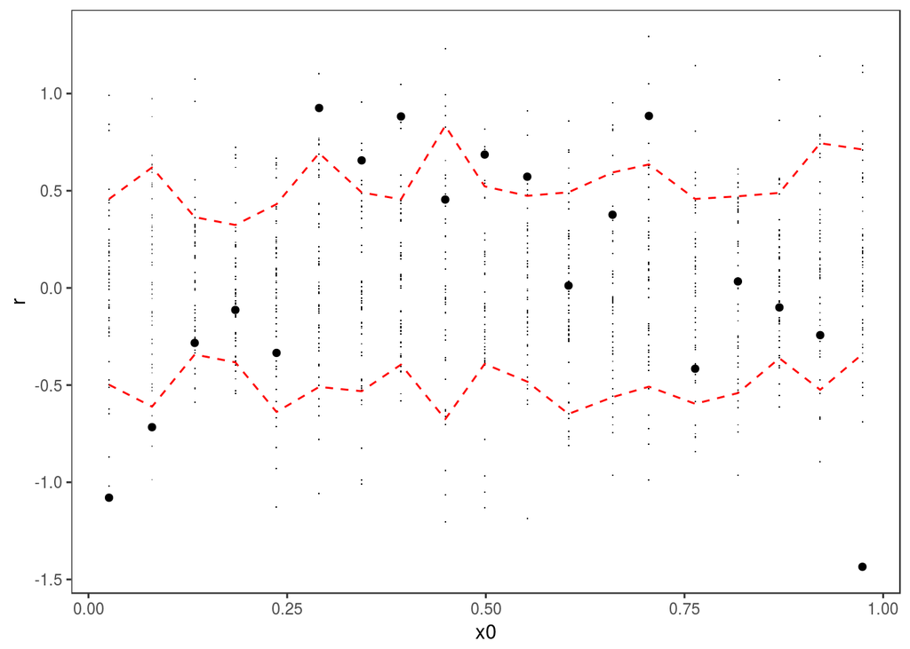

```r
check1D(fit1, "x0") + l_gridCheck1D(mean)
```

There is definitely a pattern here. An analogous plot along `x2` also shows a residual pattern, hence we consider the model:

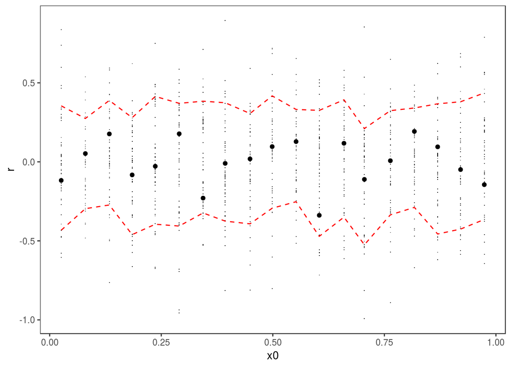

```r
fit2 <- gamV(y ~ s(x0, k = 10) + x1 + s(x2, k = 10) + x3,
             data = dat,
             aViz = list(nsim = 50))

check1D(fit2, "x0") + l_gridCheck1D(mean)
```

Looks much better, and leads to much lower AIC:

```r
AIC(fit1, fit2)
```

```
##           df      AIC
## fit1  6.0000 5031.867
## fit2 17.0879 4290.048
```

Now we check whether spline bases were large enough:

```
##
## Method: REML   Optimizer: outer newton
## full convergence after 7 iterations.
## Gradient range [-3.19235e-05,2.84903e-05]
## (score 2159.854 & scale 4.194351).
## Hessian positive definite, eigenvalue range [1.30393,497.5335].
## Model rank =  21 / 21
##
## Basis dimension (k) checking results. Low p-value (k-index<1) may
## indicate that k is too low, especially if edf is close to k'.
##
##         k'  edf k-index p-value
## s(x0) 9.00 4.11    0.98    0.19
## s(x2) 9.00 8.51    1.02    0.68
```

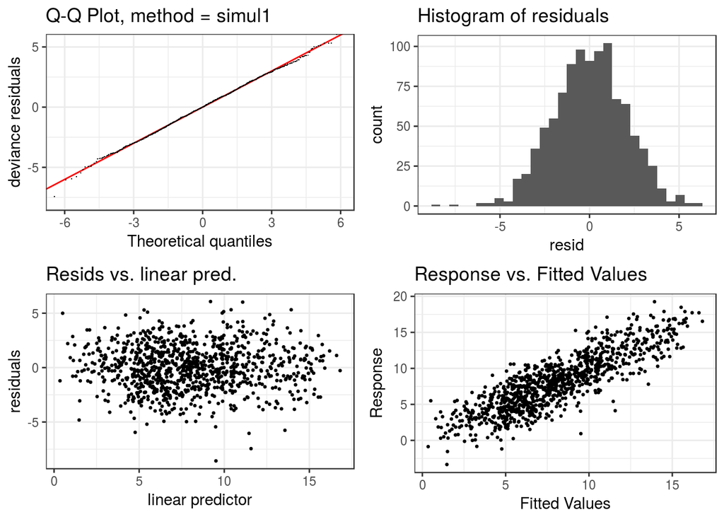

```r
check(fit2)  # check() calls check.gamViz(). See ?check.gamViz
```

Maybe we should increase `k` for `x2`.

We can plot all the smooth effects by doing:

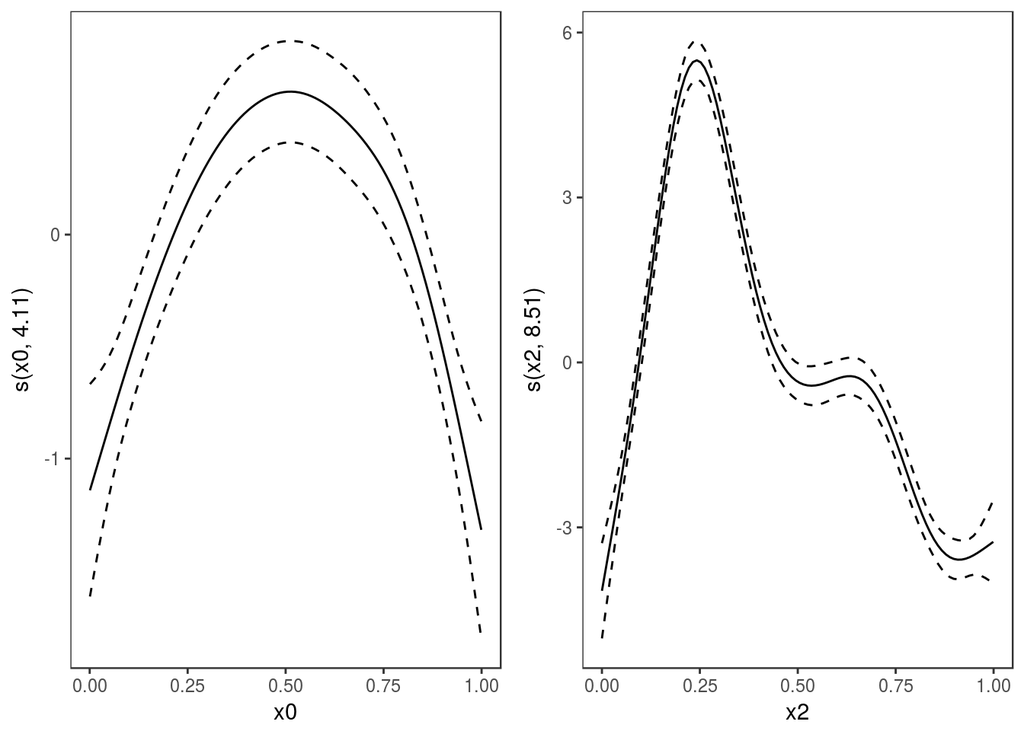

```r
print(plot(fit2), pages = 1)
```

To print only the second we do:

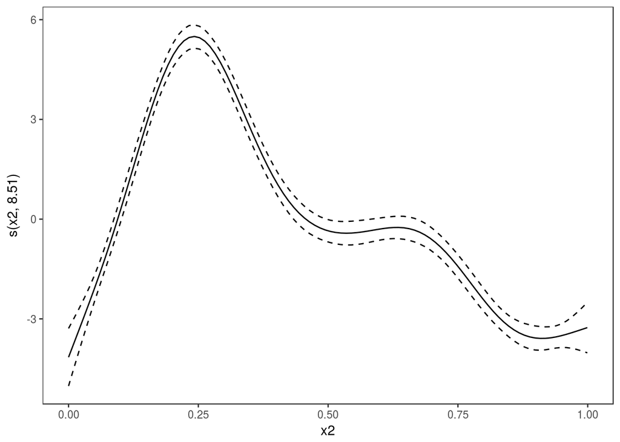

```r
plot(fit2, select = 2)
```

We get p-values etc by doing:

```r
summary(fit2)
```

```
##
## Family: gaussian
## Link function: identity
##
## Formula:
## y ~ s(x0, k = 10) + x1 + s(x2, k = 10) + x3
##
## Parametric coefficients:
##             Estimate Std. Error t value Pr(>|t|)
## (Intercept)   4.7505     0.1715  27.702   <2e-16 ***
## x1            6.2293     0.2226  27.989   <2e-16 ***
## x3            0.2133     0.2278   0.936    0.349
## ---
## Signif. codes:  0 '***' 0.001 '**' 0.01 '*' 0.05 '.' 0.1 ' ' 1
##
## Approximate significance of smooth terms:
##         edf Ref.df      F  p-value
## s(x0) 4.111  5.068  15.72 4.92e-15 ***
## s(x2) 8.509  8.932 204.82  < 2e-16 ***
## ---
## Signif. codes:  0 '***' 0.001 '**' 0.01 '*' 0.05 '.' 0.1 ' ' 1
##
## R-sq.(adj) =  0.722   Deviance explained = 72.7%
## -REML = 2159.9  Scale est. = 4.1944    n = 1000
```

# Big Data GAM modelling

The main Big Data fitting functions we are going to use are:

- `bam()` from the `mgcv` package fits an GAM models, and returns an object of class `gam`. See `?gamObject`.
- `bamV()` from the `mgcViz` package is a wrapper around `bam`. It returns `gamViz` objects.

```r
library(mgcViz)
dat <- gamSim(eg = 2, n = 1e5, dist = "normal", scale = 0.5, verbose = TRUE)
```

```
## Bivariate smoothing example
```

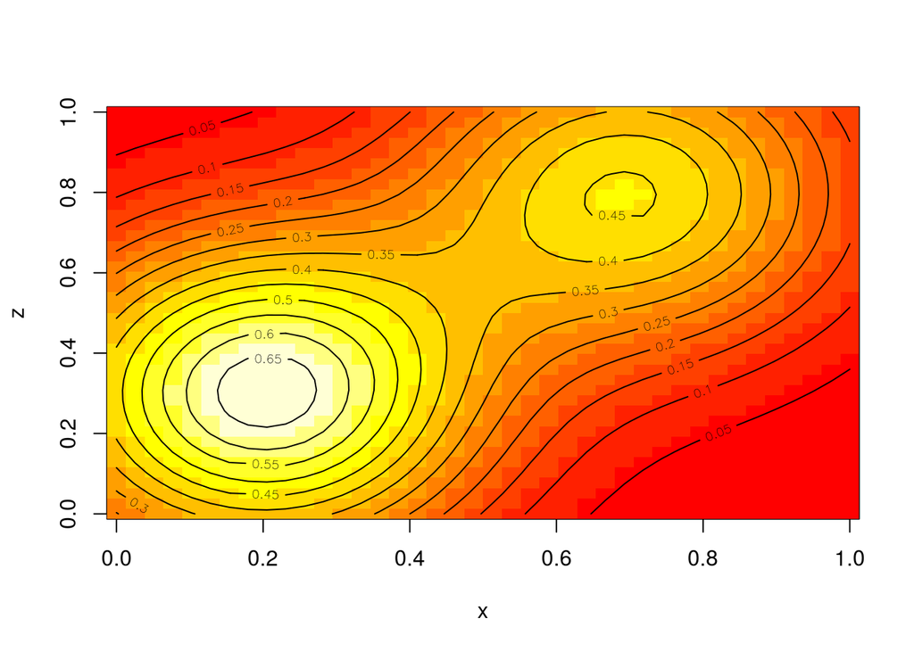

```r
truth <- dat$truth
dat <- dat$data

image(truth$f, xlab = "x", ylab = "z")
contour(truth$x, truth$z, truth$f, add = TRUE)
```

Fiting a Big Data GAM:

```r
fit <- bamV(y ~ s(x, z, k = 6),           # isotropic smooth
            data = dat,
            aGam = list(discrete = TRUE,  # arguments going to bam(). See ?bam
                        nthreads = 2),
            aViz = list(nsim = 50)        # arguments going to getViz(). See ?getViz
            )
```

Plotting the smooth effect:

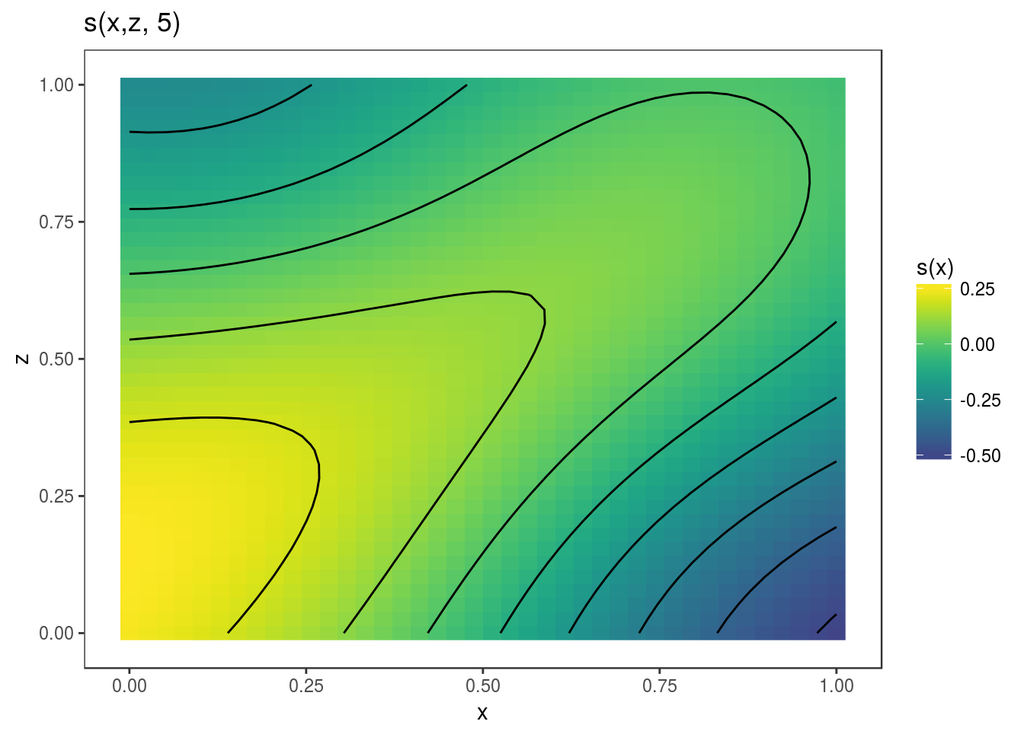

```r
plot(fit)
```

Marginal residuals checks:

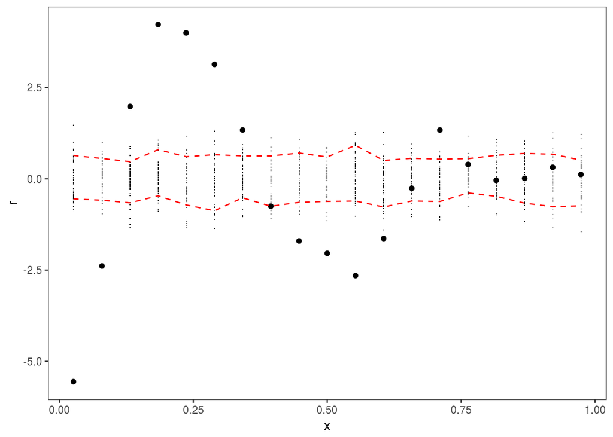

```r
check1D(fit, "x") + l_gridCheck1D()
```

Same but across two dimensions:

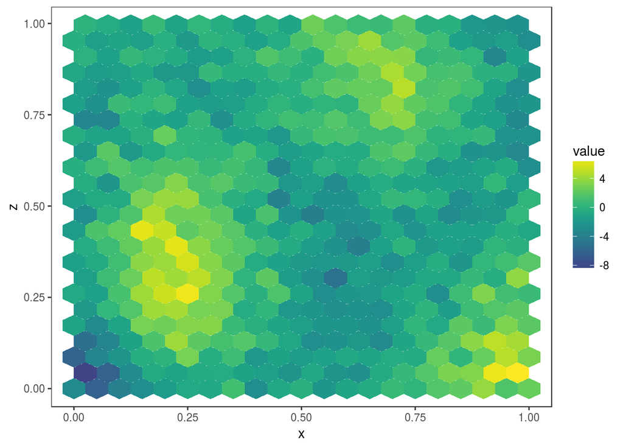

```r
check2D(fit, "x", "z") + l_gridCheck2D(bw = c(0.05, 0.05))
```

The visual check above shows a massive residuals pattern. This goes away by increasing `k`:

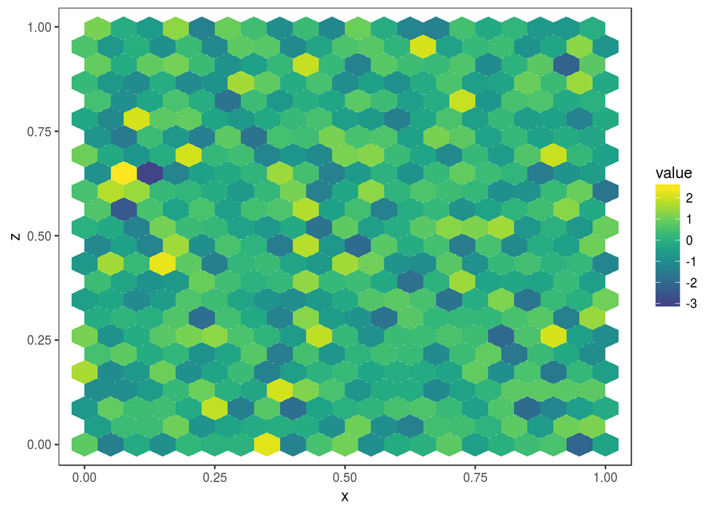

```r
fit2 <- bamV(y ~ s(x, z, k = 100),         # isotropic smooth
             data = dat,
             aGam = list(discrete = TRUE,  # arguments going to bam(). See ?bam
                         nthreads = 2),
             aViz = list(nsim = 50)        # arguments going to getViz(). See ?getViz
)

check2D(fit2, "x", "z") + l_gridCheck2D( )
```

Alternatively we can use a tensor product smooth:

```r
fit3 <- bamV(y ~ te(x, z, k = c(10, 10)),    # anisotropic smooth
             data = dat,
             aGam = list(discrete = TRUE,
                         nthreads = 2),
             aViz = list(nsim = 50)
)
```

Or we can decompose it in marginal smooth and interaction term:

```r
fit4 <- bamV(y ~ ti(x, k = 10) +             # Marginal for x
                 ti(z, k = 10) +             # Marginal for y
                 ti(x, z, k = c(10, 10)),    # anisotropic smooth interaction
             data = dat,
             aGam = list(discrete = TRUE,
                         nthreads = 2),
             aViz = list(nsim = 50)
)
```

We can plot the marginals and the interaction separately:

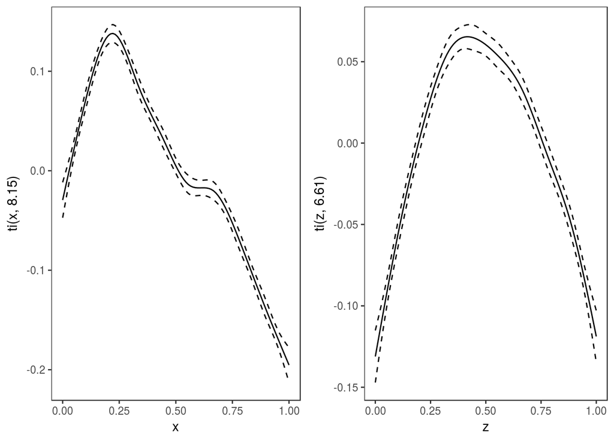

```r
print(plot(fit4, select = 1:2), pages = 1)
```

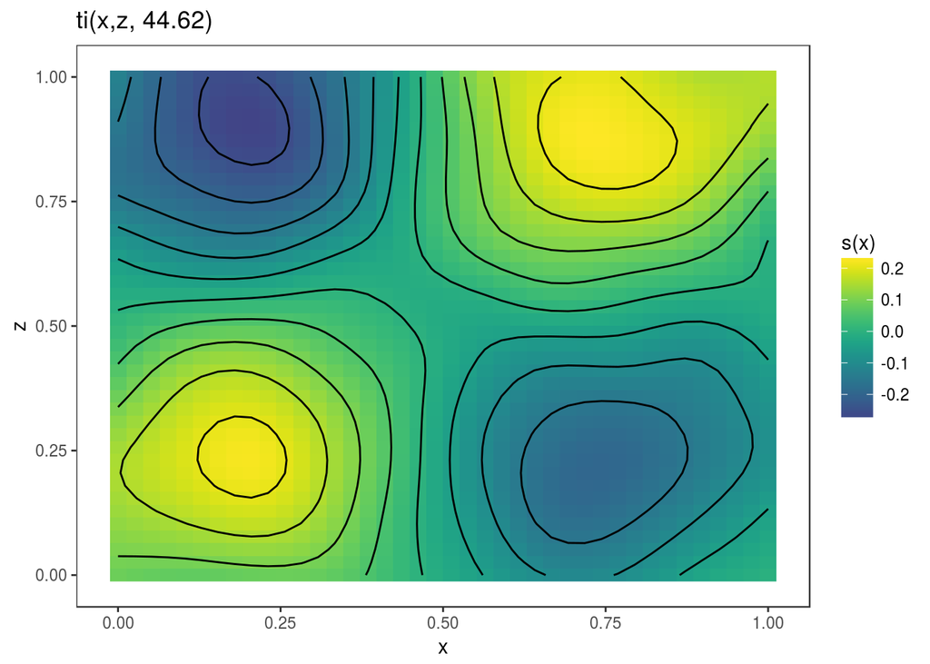

```r
plot(fit4, select = 3)
```

We can also extract the tensor interaction and plot it interactively:

```r
tmp <- sm(fit4, 3)
plotRGL(tmp, residuals = TRUE) # Will not appear in the .html file
```

# Extra things

Things that I haven’t explained (but you might find in the exercises):

- 1. the use of `offset()` in model formula
- 2. how to extract smooth effects using `sm` and add layers to plots
- 3. how to use the `select = TRUE` argument in `gam` to do variable selection
- 4. the use of the `id` argument as in `s(x, id = 1) + s(x, id = 2)`

Here I provide a very basic explanation for each.

##### 1) Use of `offset()`

Suppose we want to model fish egg counts $y$ as a function of spatial location and of other factors `x` (as in one of the exercises). If we use a Poisson model with log-link then our model for the expected number of eggs is:
$$\log{\mathbb{E}(y|{\bf x})} = f_1({\bf x}) + \cdots + f_m({\bf x}),$$
or equivalently
$$\mathbb{E}(y|{\bf x}) = \exp \{f_1({\bf x}) + \cdots + f_m({\bf x}) \}.$$
Suppose that the $i$-th egg count $y_i$ has been obtained using a fishing net of $m_i$ square meters. Then $\mathbb{E}(y_i|x_i)$ should be directly proportional $m_i$. That is, we don’t want to estimate the effect of $m$ because it is clear that (everything else being equal) double $m$ will doubling the expected number of eggs we will catch. Hence we would like our model to be
$$\log{\mathbb{E}(y|{\bf x})} = \log(m) + f_1({\bf x}) + \cdots + f_m({\bf x}),$$
so that
$$\mathbb{E}(y|{\bf x}) = m\exp \{f_1({\bf x}) + \cdots + f_m({\bf x}) \}.$$
This can be achieved by adding an `offset` terms to the linear predictor:

```r
fit <- gam(eggs ~ offset(log.m) + s(x), family = poisson(link = "log"))
```

where `log.m` is $\log(m)$.

##### 2) Extracting smooth effects using `sm()` and adding layers to plots

Suppose we are fitting this model

```r
dat <- gamSim(1,n=1000,dist="normal",scale=2)
```

```
## Gu & Wahba 4 term additive model
```

```r
b <- gamV(y ~ x0+s(x1, x2)+s(x3), data=dat)
```

We could plot the estimated effects as usual using `plot(fit)` but, alternatively, we can extract individual smooth effects using `sm` and then plot them:

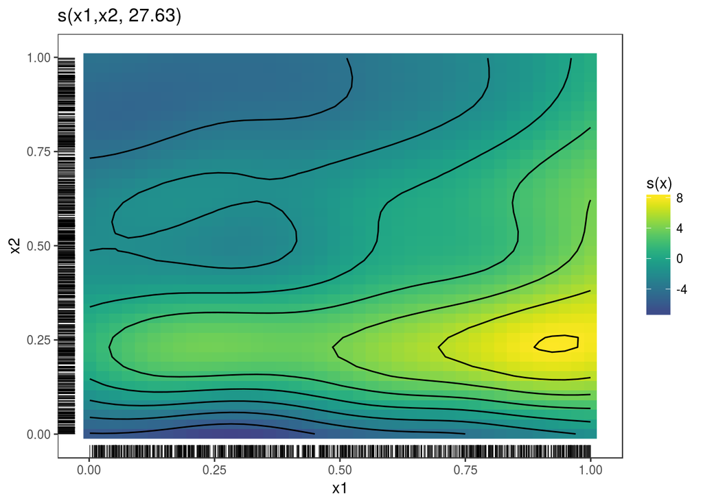

```r
s1 <- sm(b, 1)
plot(s1) + l_rug() + l_fitRaster() + l_fitContour()
```

The functions starting with `l_` are graphical layers, similar to `ggplot` layers. To see which layes are available for a particular effect we can do:

```r
listLayers( plot(s1) )
```

```
## [1] "l_fitContour" "l_fitRaster"  "l_dens"       "l_points"
## [5] "l_rug"
```

which prints out a list of available layers. We can do the same for parametric effects, using the `pterm` function:

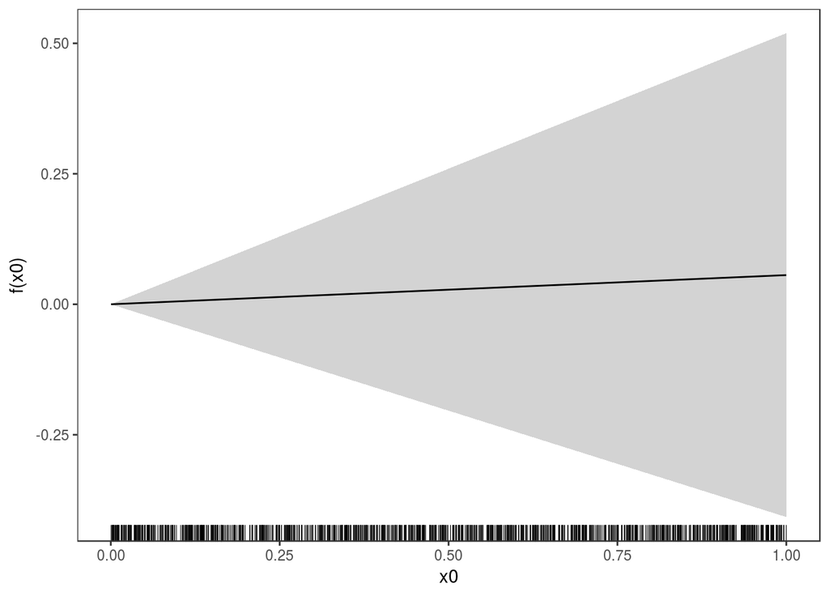

```r
p1 <- pterm(b, 1)
plot(p1) + l_rug() + l_ciPoly() + l_fitLine()
```

##### 3) Using `select = TRUE` in `gam` to do variable selection

We simulate data from the model
$$y = x^2 + e, \;\;\; e \sim N(0, \sigma^2),$$
by doing:

```r
set.seed(42424)
n <- 1000
x <- runif(n, -1, 1)
dat <- data.frame(y = x^2 + rnorm(n, 0, 1), x = x, z = runif(n, -1, 1))
```

Notice that I have added an extra variable `z` which has nothing to do with the distribution of `y`. Now I fit the model

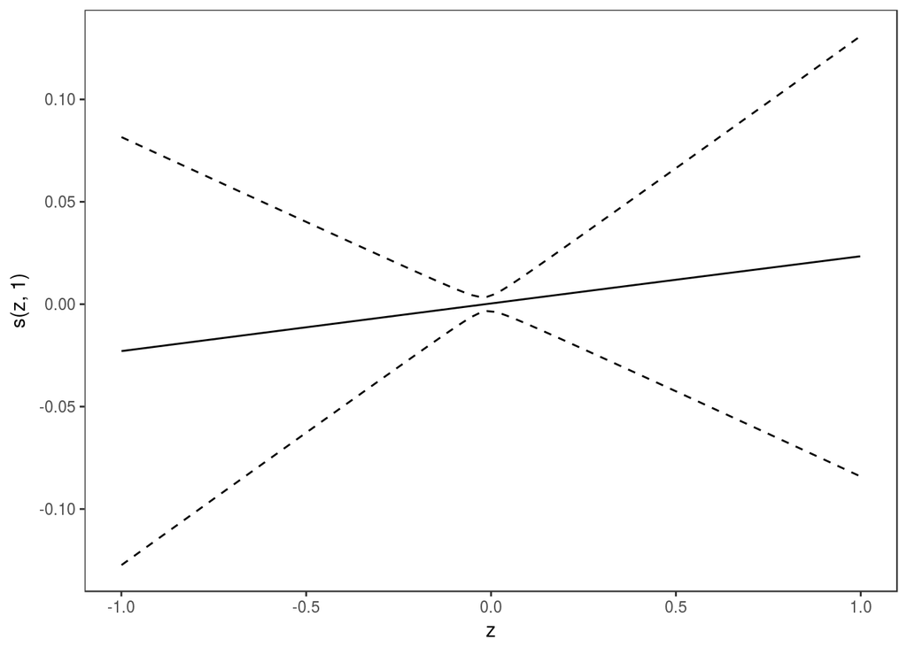

```r
fit <- gamV(y ~ s(x) + s(z), data = dat)
plot(fit, select = 2)
```

Notice that the estimated effect of `z`, while weak, is not zero. This is because the penalty used by `mgcv` penalises the curvature of `s(z)`, not its slope. To penalise also the slope of the effect `s(z)` we can use the `select` argument:

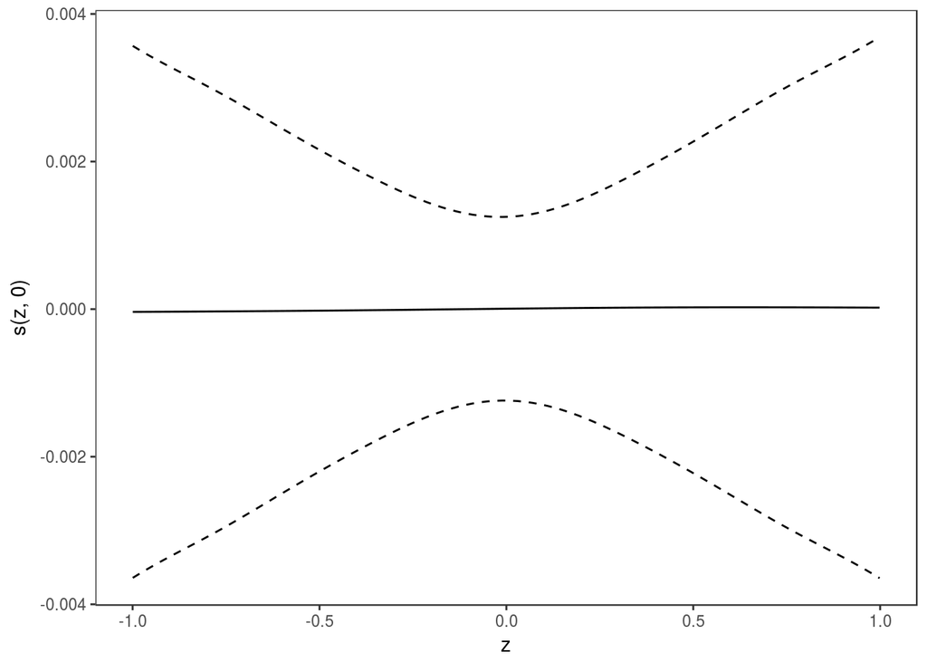

```r
fit <- gamV(y ~ s(x) + s(z), data = dat, aGam = list(select = TRUE))
print(plot(fit, select = 2), page = 1)
```

Now the whole effect, that is both its smooth and parametric part, has been effectively removed from the fit.

##### 4) Using the `id` argument when creating smooth effects

Suppose we are fitting a model with two by-factor smooth:

```r
fit <- gamV(y ~ s(x1, by = Factor1) + s(z2, by = Factor2) + s(x3), ...)
```

By default the smoothing parameter of `s(x1)` will be different for each level of factor variable `Factor1`. Same for `s(x2)` and `Factor2`. We can make so that only one smoothing parameter will be used for each of the two by-factor effects by doing:

```r
fit <- gamV(y ~ s(x1, by = Factor1, id = 1) + s(z2, by = Factor2, id = 2) + s(x3), ...)
```

This model has 3 smoothing parameters, so all the smooths along `x1` have the same smootness penalty. Same for `x2`. If we do:

```r
fit <- gamV(y ~ s(x1, by = Factor1, id = 1) + s(z2, by = Factor2, id = 1) + s(x3), ...)
```

Then we are using only 2 smoothing parameters, and all the smooths along `x1` and `x2` have the same penalty (which is typically undesirable). See `?s` for more details.

# References

Wood S. N. (2017) Generalized additive models: an introduction with R. Second edition. Chapman and Hall/CRC, 2017.